# **BIOINFORMATICS FINAL PROJECT**

## *PUMA CONCOLOR*: STUDY OF ECUADORIANS POPULATIONS

### RESEARCH QUESTIONS

1. **What type of data/input will be used?**

   Genetic sequences collected from museums or researches.
2. **What format will the data be in?**

   FASTA format
3. **What will be done with this data?**

The genomic analysis tools will be applied to study and determine the status of puma populations in mainland Ecuador.

### ECOLOGICAL DATA

In the following link, you will find ecological information about the species provided by the BIOWEB by the Pontificia Universidad Catolica del Ecuador. (https://bioweb.bio/faunaweb/mammaliaweb/FichaEspecie/Puma%20concolor#!)

#### Puma’s geographic distribution

Pumas have a wide distribution across the Americas.

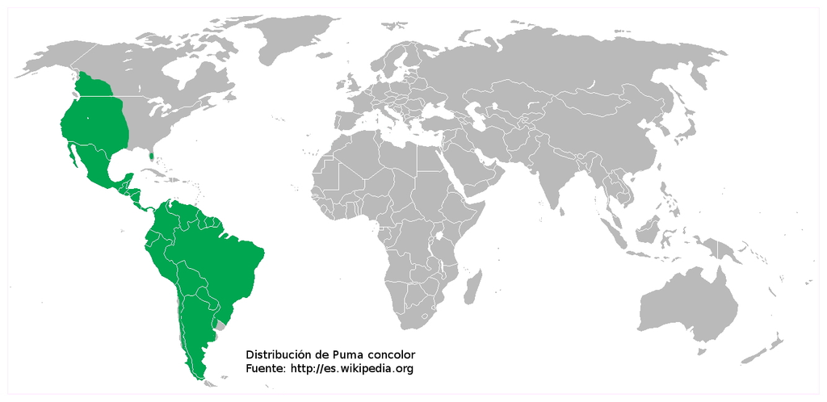

**Figure 1.** Puma’s distribution

#### Gallery

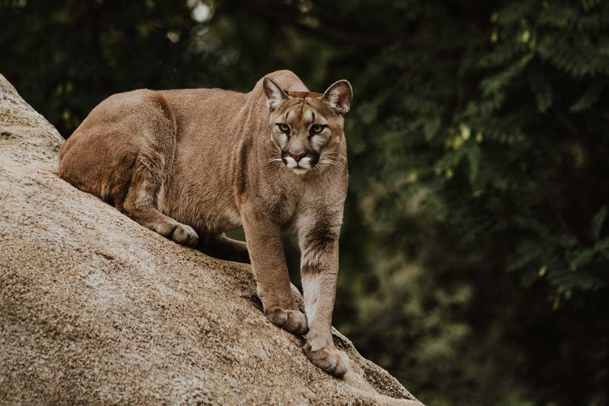

Puma concolor

[video not shown]

### REFERENCE PAPER: **Molecular evidence for a recent demographic expansion in the puma (Puma concolor) (Mammalia, Felidae)**

*DOI: https://doi.org/10.1590/s1415-47572013000400018*

Genetic data were gathered from the study conducted by Eunice Matte and colleagues (2013), which extends previous phylogeographic findings, reassessing the delimitation of historical population units in South America. The study demonstrates that this species underwent a significant demographic expansion in the Holocene, around 8,000 years ago. The sequences can be found as a PopSet under the accession code: **572098819**.

#### **Methods**

The applied methods for this project involved commands learned in GitBash throughout the semester to align sequences and generate phylogenetic trees. The detailed script, data, and results are available in the repository resources.

#### **Results**

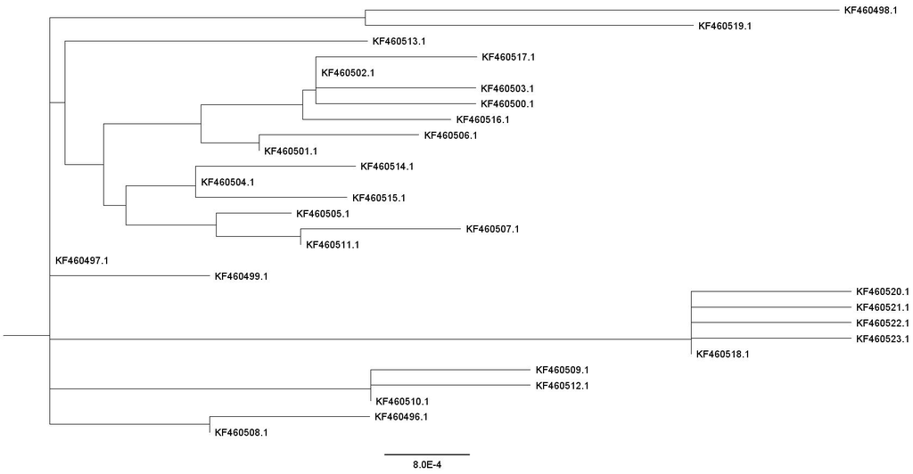

#### **Discussion**

The study highlights evidence of recent demographic expansion in the evolutionary history of the puma, possibly linked to habitat changes and prey availability. It underscores the importance of genetic diversity in species conservation, as greater genetic diversity can enhance adaptive capacity to environmental changes and diseases. Additionally, the study discusses the direct implications of its findings on puma conservation and management strategies, emphasizing the importance of maintaining genetic corridors and healthy populations.

Comparisons with previous studies on puma genetics in different regions are made to place current findings within a broader research framework. This underscores the necessity of understanding the evolutionary history and genetic diversity of pumas for their long-term conservation.